Rugby has faced many controversies and alleged conspiracies. Was rugby [complicit](https://en.wikipedia.org/wiki/1981_South_Africa_rugby_union_tour) in [apartheid](http://www.teara.govt.nz/en/photograph/26666/all-white-all-blacks-1928)? Whatever happened to [Keith Murdoch](http://www.smh.com.au/rugby-union/union-news/the-murdoch-myth-all-blacks-legend-lives-life-of-a-recluse-after-infamous-punch-20111020-1mb2p.html)? Did [Suzie the waitress](https://en.wikipedia.org/wiki/1995_Rugby_World_Cup_Final) really do it? One ongoing controversy concerns the extent to which international rugby teams “poach” players from other countries. Most of the heat is usually directed toward New Zealand, who are accused of being particularly predatory in their foreign recruitment.[^1] This debate among the international rugby public and media has largely relied on casual observations and anecdotes rather than evidence.[^2] To bring some sanity to the discussion, I built a dataset of the birthplace and playing statistics of every international rugby player to have played a test match for the 10 “major” nations.[^3] You can explore the data and maybe help me fill out a couple missing datapoints below.

I focus below on players making their debut in the professional era (post 1996) and define a foreign player as someone who was not born in the country for which they played.[^4] The following table shows that, on average, 215 players debuted for each country since 1996, ranging from 176 for Scotland to 336 for Argentina.[^5]

#### Player Debuts in the Professional Era (1996 - 2016)

|  | **Argentina** | **Australia** | **England** | **France** | **Ireland** | **Italy** | **New Zealand** | **Scotland** | **South Africa** | **Wales** |
| --- | --- | --- | --- | --- | --- | --- | --- | --- | --- | --- |
| Native | 294 | 136 | 177 | 235 | 135 | 134 | 165 | 100 | 210 | 153 |
| Foreign | 4 | 43 | 44 | 24 | 43 | 59 | 29 | 76 | 10 | 40 |
| Total | 336 | 179 | 221 | 261 | 178 | 194 | 194 | 176 | 220 | 193 |

Much of the debate assumes an increasing trend in foreign born players. The graph below presents the total number of foreign players making their debut in each year for the 10 major nations. Although there was a surge in the number of foreign players in 2016, there is otherwise no noticeable trend. There were more foreign born players in 2002 than 2015, for example, and the number has generally fluctuated around an average of 18 foreign born debutants per year, with a low of 7 in 2007 and a high of 30 in 2016.

#### Foreign Born Trend

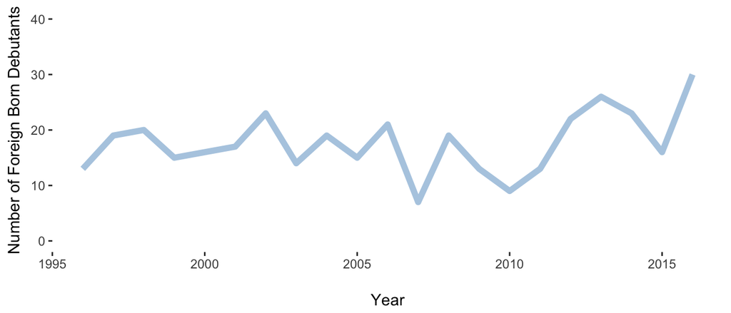

#### Foreign Born Players

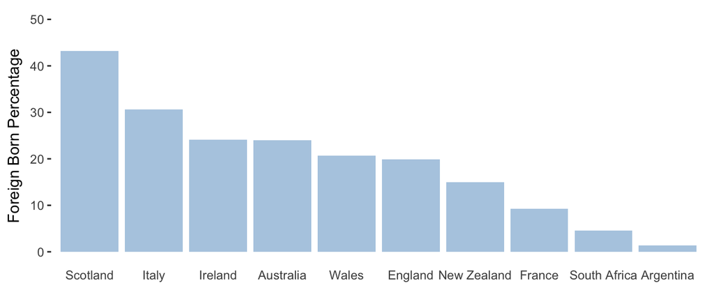

It shouldn’t be surprising that every team has foreign born players. International migration is a reality of the modern world, and many top rugby countries have large foreign born populations. The following graph compares the foreign born composition of each team to the general population in that country.[^6] The blue bars repeat the foreign born player percentages from the graph above and the red bars show the percentage of each country’s population that was foreign born. Australia has the highest proportion of its population born overseas, at 28.2%, followed by New Zealand with 23% and Ireland with 15.9%. By comparing each country’s respective blue and red bars, we see that Argentina, Australia, France, New Zealand and South Africa have rugby teams which *under*-represent the foreign-born population. Foreign-born players are *over*-represented for every other country.

#### Foreign Born Players vs Foreign Born Populations

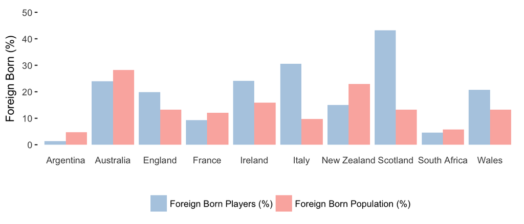

The prevalence of Pacific born players in foreign teams has garnered particular interest with the rugby public and media, although just 3 of the top 10 major countries have had more than two players born in the Pacific Island nations of Samoa, Fiji, and Tonga since 1996.[^7] 13 Wallabies, 4 English players and 21 All Blacks were born in the Pacific. However, these numbers do not tell the full story because each country has vastly different Pacific populations. 2.8% of the New Zealand population were born in the Pacific Islands, compared to just 0.5% in Australia and less than 0.1% in England.[^8] Pacific athletes are wonderful rugby players, and it is unsurprising that they are *over*-represented in all these teams. However, the extent to which they are over represented differs markedly across teams. While New Zealand has 4 times more Pacific born players than would be expected given the population, Australia has 16 times more, and England a whopping 162 times more.

#### Pacific Born Players vs Pacific Born Populations

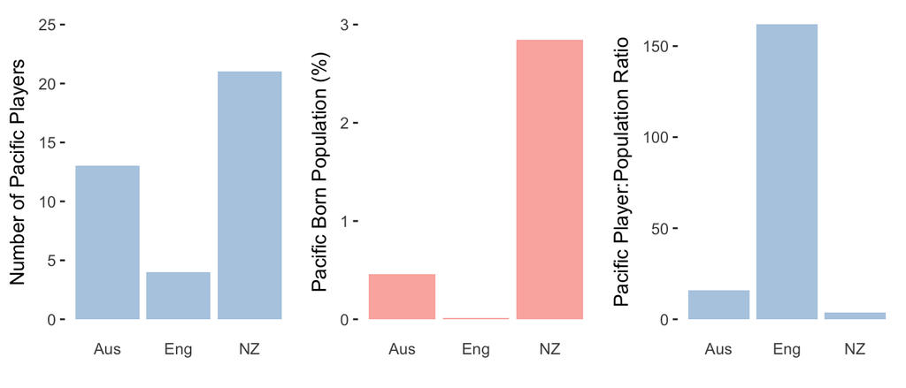

The graph below shows the top 10 “suppliers” of players to the rest of the world, which includes all countries for which I have data.[^9] 229 New Zealanders have played for another country. The next largest exporter is England with 95 players. Notable among this list are Samoa, Tonga and Fiji, which together have contributed 63 players to the international rugby community. Notable absences include Scotland, Ireland and Wales, which have provided fewer than 7 players each to other countries, despite having had the services of 159 foreign born players combined.

#### Exports of Foreign Players

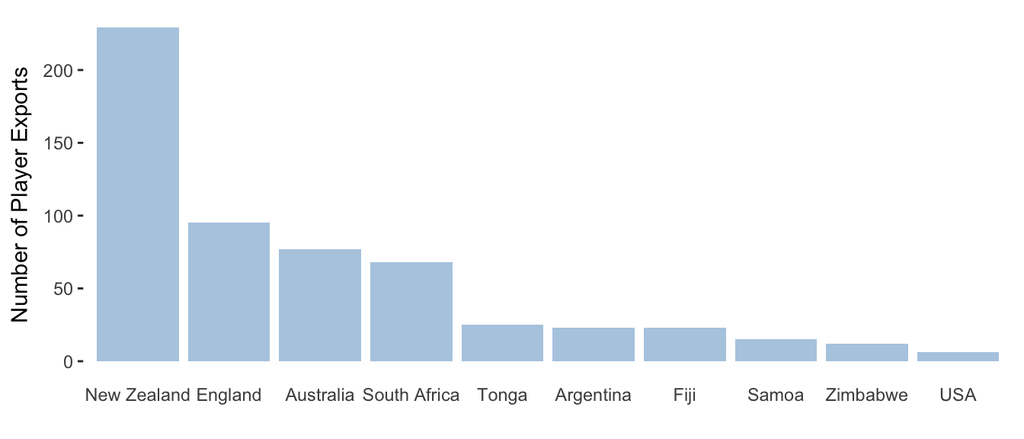

The next graph summarises the net contribution of each country to the international rugby stock. The “trade balance” is calculated by subtracting the number of “imported” players from the number of “exported” players. A positive trade balance indicates that a country contributes more players to other countries than it “poaches”. Leading the way is New Zealand, which has provided 200 more players to other countries than it has poached. On the other side of the ledger is Scotland, which has imported 70 more players than it has exported.

#### The Trade Balance

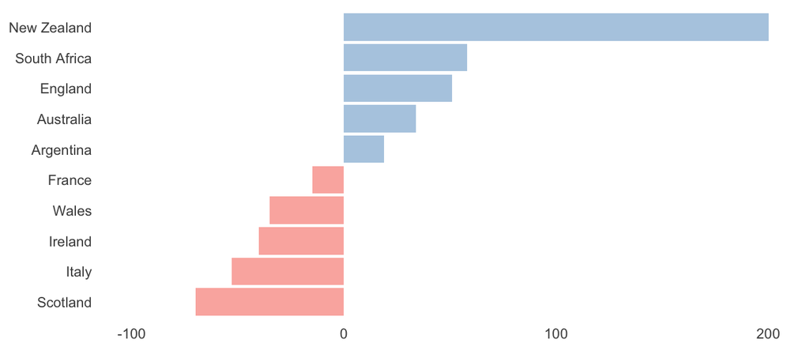

#### Player Contributions

| **Team** | **Points per Native Player** | **Points per Foreign Player** | **Tries per Native Player** | **Tries per Foreign Player** | **Matches per Native Player** | **Matches per Foreign Player** |
| --- | --- | --- | --- | --- | --- | --- |
| Argentina | 20.1 | 16.2 | 2.3 | 3.2 | 12.6 | 18.5 |
| Australia | 33.7 | 25.5 | 3.9 | 3.7 | 27.5 | 24.9 |
| England | 31.6 | 7.6 | 3.1 | 1.5 | 21.4 | 13.8 |
| France | 22.1 | 12.3 | 2.0 | 2.2 | 16.7 | 20.9 |
| Ireland | 27.8 | 38.1 | 3.3 | 2.7 | 25.1 | 21.3 |
| Italy | 11.1 | 27.9 | 1.4 | 2.1 | 18.2 | 26.6 |
| New Zealand | 41.6 | 30.5 | 4.8 | 6.1 | 24.1 | 22.4 |
| Scotland | 27.0 | 15.4 | 2.2 | 2.0 | 26.7 | 18.9 |
| South Africa | 26.7 | 103.1 | 3.1 | 5.0 | 20.6 | 30.9 |
| Wales | 29.7 | 21.4 | 2.6 | 3.8 | 23.3 | 24.2 |

#### Dataset

You can scroll and search the dataset below, which contains every player from the ten major countries who debuted after 1900. You can download the full dataset [here](https://github.com/hautahi/Rugby-Wanderers/raw/master/data/1.main_data.csv), or you can view each of the individual team datasets at the following links ([Argentina](https://github.com/hautahi/Rugby-Wanderers/blob/master/data/Argentina.csv), [England](https://github.com/hautahi/Rugby-Wanderers/blob/master/data/England.csv), [Australia](https://github.com/hautahi/Rugby-Wanderers/blob/master/data/Australia.csv), [New Zealand](https://github.com/hautahi/Rugby-Wanderers/blob/master/data/NewZealand.csv), [Scotland](https://github.com/hautahi/Rugby-Wanderers/blob/master/data/Scotland.csv), [Ireland](https://github.com/hautahi/Rugby-Wanderers/blob/master/data/Ireland.csv), [Wales](https://github.com/hautahi/Rugby-Wanderers/blob/master/data/Wales.csv), [South Africa](https://github.com/hautahi/Rugby-Wanderers/blob/master/data/SouthAfrica.csv), [Japan](https://github.com/hautahi/Rugby-Wanderers/blob/master/data/Japan.csv), [Samoa](https://github.com/hautahi/Rugby-Wanderers/blob/master/data/Samoa.csv), [Fiji](https://github.com/hautahi/Rugby-Wanderers/blob/master/data/Fiji.csv), [Tonga](https://github.com/hautahi/Rugby-Wanderers/blob/master/data/Tonga.csv), [Canada](https://github.com/hautahi/Rugby-Wanderers/blob/master/data/Canada.csv), [USA](https://github.com/hautahi/Rugby-Wanderers/blob/master/data/USA.csv), [Italy](https://github.com/hautahi/Rugby-Wanderers/blob/master/data/Italy.csv), [France](https://github.com/hautahi/Rugby-Wanderers/blob/master/data/France.csv)). The Python and R programs that document both the data scraping and adjustments are available at the [Rugby Wanderers Github Repository](https://github.com/hautahi/Rugby-Wanderers).

| Name | Team | Debut | Tests | Pts | Tries | Birthplace | Birthcountry |
| --- | --- | --- | --- | --- | --- | --- | --- |
| Simon Berghan | Scotland | 2017 | 3 | 0 | 0 | Christchurch | New Zealand |
| Cornell du Preez | Scotland | 2017 | 2 | 0 | 0 | Port Elizabeth | South Africa |
| Niall Scannell | Ireland | 2017 | 4 | 0 | 0 | Cork | Ireland |
| Andrew Conway | Ireland | 2017 | 1 | 0 | 0 | Dublin | Ireland |
| Arthur Iturria | France | 2017 | 1 | 0 | 0 | Bayonne | France |
| Henry Chavancy | France | 2017 | 1 | 0 | 0 | Strasbourg | France |
| Fabien Sanconnie | France | 2017 | 2 | 0 | 0 | Larche, Correze | France |
| Antoine Dupont | France | 2017 | 2 | 0 | 0 | Lannemezan | France |
| Luca Sperandio | Italy | 2017 | 2 | 0 | 0 | Treviso | Italy |
| Federico Ruzza | Italy | 2017 | 1 | 0 | 0 | Padova | Italy |

[output cut: 8669 more lines]

To my knowledge, the player names and playing statistics are accurate (as at May 15, 2017), but the birthplace information remains a work in progress. The data is especially sparse for Canada, the USA, Argentina and the Pacific Island countries. I welcome any contributions and corrections. Feel free to email me (hautahikingi@gmail.com) with any help you can provide.

[^1]: Here are a few examples: [1](http://www.telegraph.co.uk/sport/rugbyunion/2361788/Ruthless-All-Blacks-harvest-fertile-Island-talent.html), [2](http://www.dailymail.co.uk/sport/rugbyunion/article-2612324/All-Blacks-remember-players-theyve-poached-Pacific-Islands.html), [3](http://www.telegraph.co.uk/sport/rugbyunion/international/newzealand/11113937/New-Zealand-owe-a-debt-to-Samoa-that-can-only-be-repaid-with-a-full-touring-party-for-long-overdue-first-Test-visit.html), [4](http://www.theroar.com.au/2012/10/31/the-problem-with-eligibility-in-international-rugby/), [5](http://www.stuff.co.nz/sport/rugby/opinion/10132272/Gifford-Home-truths-about-Pasifika-poaching), and [6](http://www.stuff.co.nz/13313/All-Blacks-accused-of-Pacific-pillage-again).
[^2]: The [New Zealand Herald](http://www.nzherald.co.nz/sport/news/article.cfm?c_id=4&objectid=11278276) provided a notable exception by compiling a dataset of the birthplace of every [All Black](https://en.wikipedia.org/wiki/New_Zealand_national_rugby_union_team) prior to 2014.
[^3]: I scraped the majority of my data from the superb [ESPNscrum](http://www.espnscrum.com) website, which lists statistics for every person to have played a test-match for the major rugby nations. As well as statistics like matches played, points and tries scored, there is also birth information for the majority of players. However, the birthplace information, where available, is limited to the city of birth. I therefore match the birth cities with their respective countries using the [Geopy](https://pypi.python.org/pypi/geopy) geocoding package in Python. This works well for city names that are unique to a particular country, such as Taumarunui. However, in the case of ambiguous city/country pairs, the Geopy package (to the best of my knowledge) returns the city with the highest population, which leads to errors. For example, the Geopy package attributes those players that were born in the town of Hastings, New Zealand as being born in Hastings, England. I therefore also make manual adjustments to the scraped datasets based on my own research. In the case of New Zealand, I use the dataset provided by the [New Zealand Herald](http://www.nzherald.co.nz/sport/news/article.cfm?c_id=4&objectid=11278276) for players making their test debut prior to 2015.  
    I define the ten major nations as those teams in the Six Nations Championship and the Rugby Championship.
[^4]: This definition has some shortcomings. For example, [Ronan O’Gara](https://github.com/hautahi/Rugby-Wanderers/blob/master/data/Ireland.csv#L957), who scored 1083 points for Ireland, is considered a foreign born player because he was born in the United States, despite the fact that few would question his Irish rugby “credentials”.
[^5]: I am missing the birth information for 41 of these players, and they are not included in this table or the rest of the analysis. 38 of the missing players are from Argentina, 2 from France and 1 from Italy.
[^6]: I use 2015 census data retrieved from the [World Bank Data Bank](http://databank.worldbank.org/data/reports.aspx?source=2&series=SM.POP.TOTL.ZS&country=#) (accessed on 12 March 2017) for foreign born populations. The dataset is [here](https://github.com/hautahi/Rugby-Wanderers/blob/master/data/WorldBankData/Data.csv) and details of the definitions and sources for each country can be found [here](https://github.com/hautahi/Rugby-Wanderers/blob/master/data/WorldBankData/DefinitionandSource.csv). I do not have separate migration data for the British countries. I therefore use the total United Kingdom figure of 13.2% for each of England, Scotland and Wales.
[^7]: While acknowledging the problematic nature of collectively labelling the diverse communities within the South Pacific, for the purposes of this discussion “the Pacific” refers to the countries of Samoa, Fiji and Tonga - the three Pacific Island countries with the largest rugby playing populations.
[^8]: These figures are calculated using 2015 [United Nations](http://www.un.org/en/development/desa/population/migration/data/estimates2/data/UN_MigrantStockByOriginAndDestination_2015.xlsx) data for Pacific born populations and [World Bank](http://data.worldbank.org/data-catalog/Population-ranking-table) data (accessed on 22 April 2017) for population counts.
[^9]: The next two graphs involving “exports” use data from all 16 countries. This is a little problematic because there are many more missing datapoints. For example, I am missing birthplace data for 42 Japan players and 58 USA players. The presented numbers therefore represent lower-bound estimates for exports and the trade balance.